# Assignment08

Frank Bonifazi

6/12/2019

Display all of your answers by simply writing the variable name at the end of the code block.

Load libraries that you need

```r
library("tidyverse")
library("DBI")
```

Connect to `chinook.db`

```r
con <- DBI::dbConnect(RSQLite::SQLite(), "chinook.db")
```

Need the correct names of the tables:

```r
# Show all tables
dbListTables(con)
```

```
##  [1] "albums"          "artists"         "customers"
##  [4] "employees"       "genres"          "invoice_items"
##  [7] "invoices"        "media_types"     "playlist_track"
## [10] "playlists"       "sqlite_sequence" "sqlite_stat1"
## [13] "tracks"
```

Find out what’s in “sqlite_sequence” & “sqlite_stat1” … ask Scott. These might be DB definitions and admin tables.

Create variables to represent the tables: `genres, albums, artists, tracks, invoices, customers, media_types`. This will make it easier to use these tables later on.

FB: Note to self…. be more consistent with naming conventions! Whay some have "_" is sloppy naming!

```r
artists = tbl(con, 'artists')
albums = tbl(con, 'albums')
genres = tbl(con, "genres")
tracks = tbl(con, "tracks")
invoices = tbl(con, "invoices")
customers = tbl(con, "customers")
media_types = tbl(con, "media_types")
invoice_items = tbl(con, "invoice_items") #FB: I added this one to Scott's list above.
```

Who are the first 10 `customers` in the database? Return only `FirstName` and `LastName` Answer using SQL and `dbGetQuery()` (not `tbl()`)

```r
qry = 'SELECT FirstName, LastName FROM customers LIMIT 10'
dbGetQuery(con, qry)
```

```
##    FirstName    LastName
## 1       Luís   Gonçalves
## 2     Leonie      Köhler
## 3   François    Tremblay
## 4      Bjørn      Hansen
## 5  František Wichterlová
## 6     Helena        Holý
## 7     Astrid      Gruber
## 8       Daan     Peeters
## 9       Kara     Nielsen
## 10   Eduardo     Martins
```

Complete the same task as above using `tbl()`

```r
#NOTE: tbl is in the customers function created above!
customers%>%
  select(FirstName,LastName) %>%
  head(10)
```

```
## # Source:   lazy query [?? x 2]
## # Database: sqlite 3.22.0 [/cloud/project/chinook.db]
##    FirstName LastName
##    <chr>     <chr>
##  1 Luís      Gonçalves
##  2 Leonie    Köhler
##  3 François  Tremblay
##  4 Bjørn     Hansen
##  5 František Wichterlová
##  6 Helena    Holý
##  7 Astrid    Gruber
##  8 Daan      Peeters
##  9 Kara      Nielsen
## 10 Eduardo   Martins
```

For the rest of the assignment, use the `tbl()` … you may use raw SQL if it is easier for you.

Count the number of `customers` by `country` and arrange in descending order.

```r
customers%>%
  select(CustomerId, Country) %>%
  group_by (Country) %>%
  summarize(n = n()) %>%
  arrange(desc(n))
```

```
## # Source:     lazy query [?? x 2]
## # Database:   sqlite 3.22.0 [/cloud/project/chinook.db]
## # Ordered by: desc(n)
##    Country            n
##    <chr>          <int>
##  1 USA               13
##  2 Canada             8
##  3 Brazil             5
##  4 France             5
##  5 Germany            4
##  6 United Kingdom     3
##  7 Czech Republic     2
##  8 India              2
##  9 Portugal           2
## 10 Argentina          1
## # … with more rows
```

```r
#show_query()
```

Plot the sum of `Total` from invoices by year in a line chart.

FB: 1st find all the fields in the invoices table! (4 missing from diag)

```r
dbListFields(con, "invoices")
```

```
## [1] "InvoiceId"         "CustomerId"        "InvoiceDate"
## [4] "BillingAddress"    "BillingCity"       "BillingState"
## [7] "BillingCountry"    "BillingPostalCode" "Total"
```

FB: Total and InvoiceDate are fields in the DB What data types are they?

```r
# class (invoices$InvoiceDate) FB: Tried to get the field type directly fron the DB, but returns "NULL".
```

```r
invoices %>%
select (InvoiceDate, Total) #%>%
```

```
## # Source:   lazy query [?? x 2]
## # Database: sqlite 3.22.0 [/cloud/project/chinook.db]
##    InvoiceDate         Total
##    <chr>               <dbl>
##  1 2009-01-01 00:00:00  1.98
##  2 2009-01-02 00:00:00  3.96
##  3 2009-01-03 00:00:00  5.94
##  4 2009-01-06 00:00:00  8.91
##  5 2009-01-11 00:00:00 13.9
##  6 2009-01-19 00:00:00  0.99
##  7 2009-02-01 00:00:00  1.98
##  8 2009-02-01 00:00:00  1.98
##  9 2009-02-02 00:00:00  3.96
## 10 2009-02-03 00:00:00  5.94
## # … with more rows
```

```r
   #summarize (InvoiceDate, sum(Total))
```

FB: I can see that InvoiceDate is a character (not date type) and Total is a numeric.

```r
invoices %>%
mutate(Date = InvoiceDate) %>%
mutate(Year_only = str_sub(Date,1,4)) %>%
mutate(Year_num = as.numeric(Year_only)) %>%
select(Year_num, Total) %>%
  group_by(Year_num) %>%
  summarize(sum(Total))
```

```
## # Source:   lazy query [?? x 2]
## # Database: sqlite 3.22.0 [/cloud/project/chinook.db]
##   Year_num `sum(Total)`
##      <dbl>        <dbl>
## 1     2009         449.
## 2     2010         481.
## 3     2011         470.
## 4     2012         478.
## 5     2013         451.
```

FB: Now tying to answer using my own tibble object

```r
InvoiceTibble = invoices %>% as_data_frame()
```

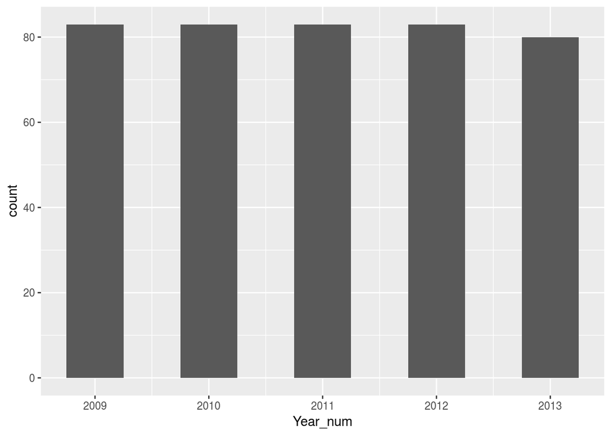

```r
InvoiceTibble %>%
  #class()
mutate(Date = InvoiceDate) %>%
mutate(Year_only = str_sub(Date,1,4)) %>%
mutate(Year_num = as.numeric(Year_only)) %>%
#This worked to create a new col with a numeric year!
  select(Year_num, Total) %>%
group_by(Year_num) %>%
ggplot(aes(x=Year_num)) +
geom_bar(binwidth=.5)
```

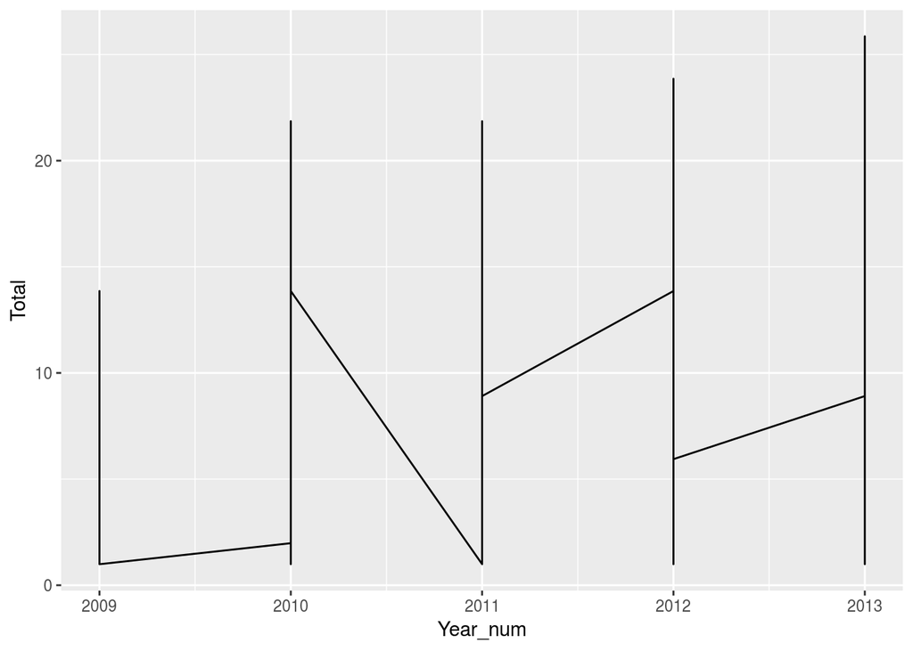

```r
InvoiceTibble = invoices %>% as_data_frame()
InvoiceTibble %>%
  #class()
mutate(Date = InvoiceDate) %>%
mutate(Year_only = str_sub(Date,1,4)) %>%
mutate(Year_num = as.numeric(Year_only)) %>%
#This worked to create a new col with a numeric year!
  select(Year_num, Total) %>%
group_by(Year_num) %>%
ggplot(aes(x=Year_num, y=Total)) +
geom_line()
```

FB: Looks way better as a bar plot!!!!

Try a boxplot…

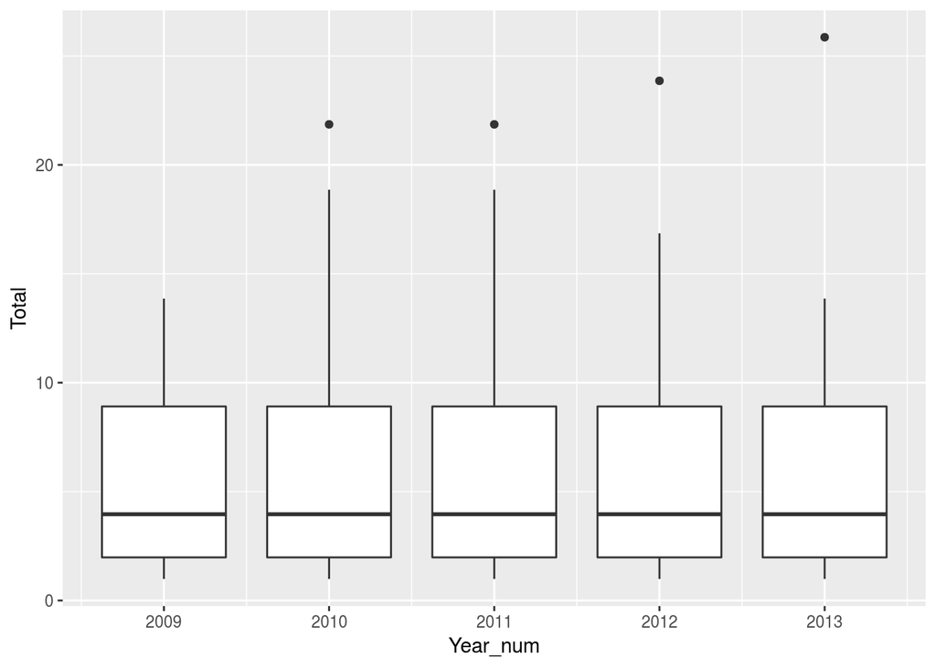

```r
InvoiceTibble = invoices %>% as_data_frame()
InvoiceTibble %>%
  #class()
mutate(Date = InvoiceDate) %>%
mutate(Year_only = str_sub(Date,1,4)) %>%
mutate(Year_num = as.numeric(Year_only)) %>%
#This worked to create a new col with a numeric year!
  select(Year_num, Total) %>%
group_by(Year_num) %>%
ggplot(aes(x=Year_num, y=Total, group=Year_num)) +
geom_boxplot()
```

FB: This is the best plot option IMO.

```r
what_is_this = albums
  class(what_is_this)
```

```
## [1] "tbl_SQLiteConnection" "tbl_dbi"              "tbl_sql"
## [4] "tbl_lazy"             "tbl"
```

FB: Looks like a tibble to me.

```r
what_is_this = albums %>%
  select(AlbumId) #FB: Needs something or else I get error...
My_tibble = (as.tibble(albums))
class(My_tibble)
```

```
## [1] "tbl_df"     "tbl"        "data.frame"
```

FB: Now trying it without using my own tibble…much clearer code!

```r
invoices %>%
mutate(Date = InvoiceDate) %>%
mutate(Year_only = str_sub(Date,1,4)) %>%
mutate(Year_num = as.numeric(Year_only)) %>%
  select (Year_num, Total) %>%
  group_by(Year_num, Total)
```

```
## # Source:   lazy query [?? x 2]
## # Database: sqlite 3.22.0 [/cloud/project/chinook.db]
## # Groups:   Year_num, Total
##    Year_num Total
##       <dbl> <dbl>
##  1     2009  1.98
##  2     2009  3.96
##  3     2009  5.94
##  4     2009  8.91
##  5     2009 13.9
##  6     2009  0.99
##  7     2009  1.98
##  8     2009  1.98
##  9     2009  3.96
## 10     2009  5.94
## # … with more rows
```

What’s the average length of a `track` for each `artist` on each `album`?

Desired Output: artist - album - track - average length

FB: Find where the data is…

1 - Length of track is field “Milliseconds” in table “tracks”

2 - “ArtistId” is in “artists” table and “albums” table

3 - Use “artists” table which matches “ArtistId” to “Name”… of artist

```r
tracks %>%
  select (AlbumId, Milliseconds)  # Don't pass anything to next line!
```

```
## # Source:   lazy query [?? x 2]
## # Database: sqlite 3.22.0 [/cloud/project/chinook.db]
##    AlbumId Milliseconds
##      <int>        <int>
##  1       1       343719
##  2       2       342562
##  3       3       230619
##  4       3       252051
##  5       3       375418
##  6       1       205662
##  7       1       233926
##  8       1       210834
##  9       1       203102
## 10       1       263497
## # … with more rows
```

```r
albums %>%
  select(AlbumId, ArtistId)# %>%
```

```
## # Source:   lazy query [?? x 2]
## # Database: sqlite 3.22.0 [/cloud/project/chinook.db]
##    AlbumId ArtistId
##      <int>    <int>
##  1       1        1
##  2       4        1
##  3       2        2
##  4       3        2
##  5       5        3
##  6       6        4
##  7       7        5
##  8       8        6
##  9      34        6
## 10       9        7
## # … with more rows
```

```r
  #left_join (tracks, by = 'AlbumId')
```

```r
  inner_join(x=tracks, y=albums) %>%
    left_join (artists, by = "ArtistId") %>%
select(ArtistId, Milliseconds, AlbumId, TrackId) %>%
  select(AlbumId, ArtistId, TrackId, Milliseconds) %>%
group_by(AlbumId, ArtistId, TrackId, Milliseconds) %>%
  summarize (mean(Milliseconds)) %>%
  arrange(desc(Milliseconds))
```

```
## # Source:     lazy query [?? x 5]
## # Database:   sqlite 3.22.0 [/cloud/project/chinook.db]
## # Groups:     AlbumId, ArtistId, TrackId
## # Ordered by: desc(Milliseconds)
##    AlbumId ArtistId TrackId Milliseconds `mean(Milliseconds)`
##      <int>    <int>   <int>        <int>                <dbl>
##  1     227      147    2820      5286953              5286953
##  2     229      149    3224      5088838              5088838
##  3     253      158    3244      2960293              2960293
##  4     253      158    3242      2956998              2956998
##  5     253      158    3227      2956081              2956081
##  6     253      158    3226      2952702              2952702
##  7     253      158    3243      2935894              2935894
##  8     253      158    3228      2927802              2927802
##  9     253      158    3248      2927677              2927677
## 10     253      158    3239      2926593              2926593
## # … with more rows
```

If the different `media_types` cost different amounts of money to sell, calculate your top 10 most profitable tracks. For this example, all costs are equal EXCEPT for the `media_type`.

COSTS:

- MPEG = $0.15
- Protected MPEG-4 = $0.25
- AAC = $0.03
- Protected AAC = $0.10
- Purchased AAC = $0.08

```r
tracks %>%
  select(MediaTypeId, UnitPrice)
```

```
## # Source:   lazy query [?? x 2]
## # Database: sqlite 3.22.0 [/cloud/project/chinook.db]
##    MediaTypeId UnitPrice
##          <int>     <dbl>
##  1           1      0.99
##  2           2      0.99
##  3           2      0.99
##  4           2      0.99
##  5           2      0.99
##  6           1      0.99
##  7           1      0.99
##  8           1      0.99
##  9           1      0.99
## 10           1      0.99
## # … with more rows
```

FB: All UnitPrice values are same… don’t differ by MediaTypeId. So, profit is determined solely by media cost.

FB: I may be missing something here… if all media types sell for the same amount 0.99, the the most profitable per unit is the one that costs the least to mfg. That’s AAC at 0.03.

But, the total profit will be based on quantiy sold. Maybe that’s what you’re after.

Scott pointed me to the media_types table where NediaTypeId lives! Will need that to map to MPEG etc.

FB: Determine which table to put the cost in. In a DB I designed, I’d probably create a new separe table for prices. One way of thinking tells me to add it to where MediaType lives… tracks table.

```r
#dbListFields(con, "media_types")
media_types %>%
select(Name, MediaTypeId)
```

```
## # Source:   lazy query [?? x 2]
## # Database: sqlite 3.22.0 [/cloud/project/chinook.db]
##   Name                        MediaTypeId
##   <chr>                             <int>
## 1 MPEG audio file                       1
## 2 Protected AAC audio file              2
## 3 Protected MPEG-4 video file           3
## 4 Purchased AAC audio file              4
## 5 AAC audio file                        5
```

FB: Let’s add Cost in the media_types table… A job for mutate man (MM!)

```r
media_types %>%
  mutate(Cost = 0) %>%  #FB: Could have set it to NA...but, O set the class the numeric.
  print(media_types)
```

```
## # Source:   lazy query [?? x 3]
## # Database: sqlite 3.22.0 [/cloud/project/chinook.db]
##   MediaTypeId Name                         Cost
##         <int> <chr>                       <dbl>
## 1           1 MPEG audio file                 0
## 2           2 Protected AAC audio file        0
## 3           3 Protected MPEG-4 video file     0
## 4           4 Purchased AAC audio file        0
## 5           5 AAC audio file                  0
```

FB: Now add the mfg costs per MediaTypeId

```r
my_media_types = as.data.frame(media_types)
Cost_vector <- c(.15, .25, .10, .08, .03)
mutate(my_media_types, Cost = Cost_vector) #Worked!
```

```
##   MediaTypeId                        Name Cost
## 1           1             MPEG audio file 0.15
## 2           2    Protected AAC audio file 0.25
## 3           3 Protected MPEG-4 video file 0.10
## 4           4    Purchased AAC audio file 0.08
## 5           5              AAC audio file 0.03
```

FB: Looking at the tracks table:

```r
dbListFields(con, "tracks")
```

```
## [1] "TrackId"      "Name"         "AlbumId"      "MediaTypeId"
## [5] "GenreId"      "Composer"     "Milliseconds" "Bytes"
## [9] "UnitPrice"
```

FB: Now all I need is to find out how many of each MedisTypeId were sold. Let’s take a look at the invoice_item table:

```r
dbListFields(con, "invoice_items")
```

```
## [1] "InvoiceLineId" "InvoiceId"     "TrackId"       "UnitPrice"
## [5] "Quantity"
```

FB: All UnitPrice values are same… don’t differ by MediaTypeId. So, profit is determined solely by media cost.

I need to match MediaTypeId to items in Scott’s cost list. Lot’s look at the invoice_items table’s invoiceItemid field

```r
dbListFields(con, "invoice_items")
```

```
## [1] "InvoiceLineId" "InvoiceId"     "TrackId"       "UnitPrice"
## [5] "Quantity"
```

FB: I found Quantity… now how do I match that up with MediaTypeId? MediaTypeId is in both the media_types and tracks tables.

```r
invoice_items %>%
  select(TrackId, Quantity)
```

```
## # Source:   lazy query [?? x 2]
## # Database: sqlite 3.22.0 [/cloud/project/chinook.db]
##    TrackId Quantity
##      <int>    <int>
##  1       2        1
##  2       4        1
##  3       6        1
##  4       8        1
##  5      10        1
##  6      12        1
##  7      16        1
##  8      20        1
##  9      24        1
## 10      28        1
## # … with more rows
```

FB: The DB table diagram is WRONG!!! - the InvoiceItemId field doesn’t exist in the invoice_items table! Scott, did you try to catch us on this?? You sneaky Devil!

```r
invoice_items %>%
  select(Quantity) %>%
  as.tibble() %>%
  unique()
```

```
## # A tibble: 1 x 1
##   Quantity
##      <int>
## 1        1
```

FB: Can it be that ALL the tracks only sold at quantity 1???

FB: Need to add MediaTypeId from the tracks table to this list… requires a join

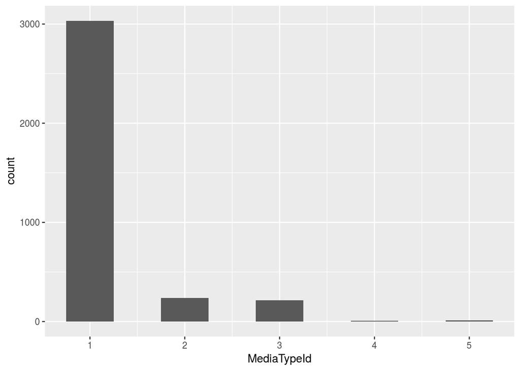

```r
media_types %>%
left_join (tracks, by = "MediaTypeId") %>%
select(MediaTypeId) %>%
  ggplot(aes(MediaTypeId)) +
  geom_histogram(binwidth=.5)
```

```r
media_types %>%
left_join (tracks, by = "MediaTypeId") %>%

left_join (invoice_items, by = "TrackId") %>%
select(TrackId, MediaTypeId,Quantity) %>%
  group_by(MediaTypeId)
```

```
## # Source:   lazy query [?? x 3]
## # Database: sqlite 3.22.0 [/cloud/project/chinook.db]
## # Groups:   MediaTypeId
##    TrackId MediaTypeId Quantity
##      <int>       <int>    <int>
##  1       1           1        1
##  2       6           1        1
##  3       7           1       NA
##  4       8           1        1
##  5       8           1        1
##  6       9           1        1
##  7       9           1        1
##  8      10           1        1
##  9      11           1       NA
## 10      12           1        1
## # … with more rows
```

FB: Weird results: Quantity is either 1 or NA.

Remove NAs?

Create a Scatter Plot of `tracks`, x = milliseconds and y = bytes

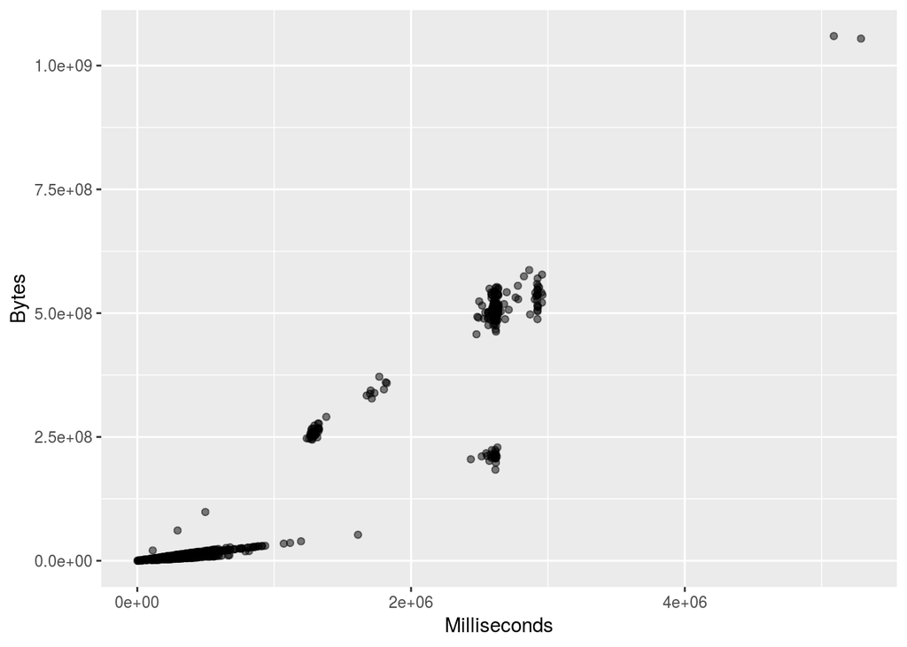

```r
  tracks %>%
  select (Milliseconds, Bytes) %>%
  ggplot(aes(x=Milliseconds, y=Bytes)) +
  geom_point(alpha =.5)
```

Create a Scatter Plot of `tracks`, x = milliseconds and y = bytes, `facet_wrap` by `media_type`

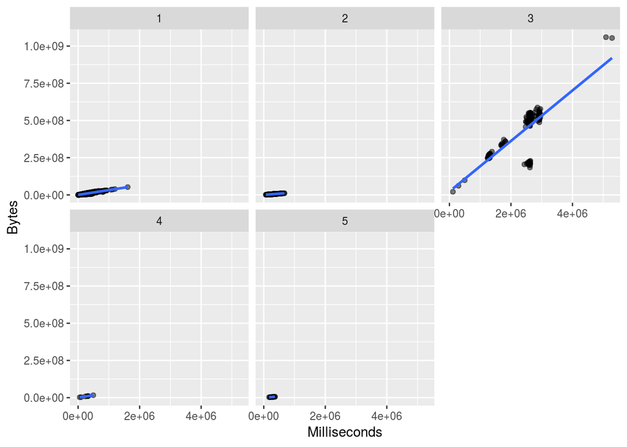

```r
  tracks %>%
  select (Milliseconds, Bytes, MediaTypeId) %>%
  ggplot(aes(x=Milliseconds, y=Bytes)) +
  geom_point(alpha =.5) +
stat_smooth(method = "lm", se = FALSE) + facet_wrap(~MediaTypeId)
```

FB: I know Scott doesn’t favor this type of regression analysis.

Create a linear regression model using `milliseconds` as a predictor of `bytes`. Hint, formula: `bytes ~ milliseconds`

```r
tracks %>%
  select(Bytes, Milliseconds)
```

```
## # Source:   lazy query [?? x 2]
## # Database: sqlite 3.22.0 [/cloud/project/chinook.db]
##       Bytes Milliseconds
##       <int>        <int>
##  1 11170334       343719
##  2  5510424       342562
##  3  3990994       230619
##  4  4331779       252051
##  5  6290521       375418
##  6  6713451       205662
##  7  7636561       233926
##  8  6852860       210834
##  9  6599424       203102
## 10  8611245       263497
## # … with more rows
```

```r
model_1 = lm(Bytes ~ Milliseconds, data=tracks)
summary(model_1)
```

```
##
## Call:
## lm(formula = Bytes ~ Milliseconds, data = tracks)
##
## Residuals:
##        Min         1Q     Median         3Q        Max
## -270086050   -6731364    2216063   10138001  137934966
##
## Coefficients:
##                Estimate Std. Error t value Pr(>|t|)
## (Intercept)  -4.094e+07  6.177e+05  -66.27   <2e-16 ***
## Milliseconds  1.891e+02  9.301e-01  203.35   <2e-16 ***
## ---
## Signif. codes:  0 '***' 0.001 '**' 0.01 '*' 0.05 '.' 0.1 ' ' 1
##
## Residual standard error: 29450000 on 3501 degrees of freedom
## Multiple R-squared:  0.9219, Adjusted R-squared:  0.9219
## F-statistic: 4.135e+04 on 1 and 3501 DF,  p-value: < 2.2e-16
```

Create a linear model using the same formula but split it out according to `media_type`

```r
tracks %>%
  select(Bytes, MediaTypeId)
```

```
## # Source:   lazy query [?? x 2]
## # Database: sqlite 3.22.0 [/cloud/project/chinook.db]
##       Bytes MediaTypeId
##       <int>       <int>
##  1 11170334           1
##  2  5510424           2
##  3  3990994           2
##  4  4331779           2
##  5  6290521           2
##  6  6713451           1
##  7  7636561           1
##  8  6852860           1
##  9  6599424           1
## 10  8611245           1
## # … with more rows
```

```r
model_2 = lm(Bytes ~ MediaTypeId, data=tracks)
summary(model_1)
```

```
##
## Call:
## lm(formula = Bytes ~ Milliseconds, data = tracks)
##
## Residuals:
##        Min         1Q     Median         3Q        Max
## -270086050   -6731364    2216063   10138001  137934966
##
## Coefficients:
##                Estimate Std. Error t value Pr(>|t|)
## (Intercept)  -4.094e+07  6.177e+05  -66.27   <2e-16 ***
## Milliseconds  1.891e+02  9.301e-01  203.35   <2e-16 ***
## ---
## Signif. codes:  0 '***' 0.001 '**' 0.01 '*' 0.05 '.' 0.1 ' ' 1
##
## Residual standard error: 29450000 on 3501 degrees of freedom
## Multiple R-squared:  0.9219, Adjusted R-squared:  0.9219
## F-statistic: 4.135e+04 on 1 and 3501 DF,  p-value: < 2.2e-16
```

Create a linear model using the same formula but split it out according to `artist`

FB: This is trickier since ArtistId is not in the same table as Bytes. It’s in the albums table.

FB: Bytes by ArtistId… ArtistId is in the artists & albums tables. Bytes is in the tracks table.

I can link from the tracks table using the AlbumId in tracks which is also in the album table.

PLAM:

- Start with artists table
- left_join albums table by ArtistId. (This will pick up AlbumId) THEN
- left_join tracks table by AlbumId. (This will pick up Bytes)

```r
artists %>%
  left_join(albums, by = "ArtistId") %>%
  left_join(tracks, by = "AlbumId") %>%
  select(Bytes, ArtistId) %>%
lm(Bytes ~ ArtistId, data = . )  %>%
summary()
```

```
##
## Call:
## lm(formula = Bytes ~ ArtistId, data = .)
##
## Residuals:
##        Min         1Q     Median         3Q        Max
## -119763572  -39842782  -21179804    2323924  999152985
##
## Coefficients:
##              Estimate Std. Error t value Pr(>|t|)
## (Intercept) -12375896    3483381  -3.553 0.000386 ***
## ArtistId       488383      32208  15.163  < 2e-16 ***
## ---
## Signif. codes:  0 '***' 0.001 '**' 0.01 '*' 0.05 '.' 0.1 ' ' 1
##
## Residual standard error: 102100000 on 3501 degrees of freedom
##   (71 observations deleted due to missingness)
## Multiple R-squared:  0.06163,    Adjusted R-squared:  0.06136
## F-statistic: 229.9 on 1 and 3501 DF,  p-value: < 2.2e-16
```